# Endophyte Erythromycin Diffusion Testing

Grace Carey

2023-02-10

## Introduction

The purpose of this document is to describe and visualize the results of the KB disk diffusion testing experiment on the AMR STRIPS 2021 root endophytes. The tables and dataframes collected will be exported into the excel file “KB_SUMMARY_061223.xlsx”. Figures will be exported into the working directory as individual files.

## Prep

Read data file into R:

Column names:

Columns in the working dataframe

| x |
| --- |
| PLATE_ID |
| ZONE_mm |
| NOTES |
| DATE PLATED |
| DATE RECORDED |
| Column |
| Antibiotic |
| Treatment |
| Column_Length |
| Destruction |
| X |
| Y |
| Block |

Samples were taken from the following columns:

Column Samples Plated

| C30 |
| --- |
| C38 |
| C36 |
| C03 |
| C09 |
| C19 |
| C32 |
| C53 |
| C04 |
| C01 |
| C48 |
| C52 |
| C43 |
| C06 |
| C12 |
| C08 |
| C29 |
| C11 |
| C14 |
| C16 |
| C39 |
| C42 |
| C25 |
| C46 |
| C05 |
| C21 |
| C33 |
| C35 |
| C44 |
| C27 |
| C49 |
| C41 |
| C37 |
| C26 |
| C02 |
| C28 |
| C23 |
| C18 |
| C17 |
| C34 |
| C40 |
| C45 |
| C24 |

These samples were plated using the standard Kirby-Bauer disk diffusion protocol. Disks were impregnated with 15ug erythromycin each. Two disks were placed on each plate, and each isolate was spread on two plates. For example, isolate C30_D1_R2_IS1_1 was plated twice: on plate C30_D1_R2_IS1_1 and on plate C30_D1_R2_IS1_2. Each plate contained two diffusion disk zones- zone A and zone B. So, zones C30_D1_R2_IS1_1A and C30_D1_R2_IS1_1B were the two zones taken from plate C30_D1_R2_IS1_1.

Cultures Plated

| C30_D1_R1_IS3_2A |
| --- |
| C30_D1_R1_IS3_1A |
| C30_D1_R1_IS3_2B |
| C30_D1_R1_IS3_1B |
| C38_D1_R2_IS2_1B |
| C38_D1_R2_IS2_2B |
| C38_D1_R2_IS2_1A |
| C30_D1_R2_IS2_1A |
| C38_D1_R2_IS2_2A |
| C30_D1_R2_IS2_2A |
| C30_D1_R2_IS2_2B |
| C30_D1_R1_IS2_2A |
| C30_D1_R2_IS2_1B |
| C30_D1_R1_IS2_1A |
| C30_D1_R1_IS2_2B |

# Examining the Data

```
## Digestate   Mineral    Manure
##  14.71179  21.91006  20.62180
```

Standard Deviation and Mean for Zone Size (mm) by Column

| Column | sd | ZONE_mm |
| --- | --- | --- |
| C30 | 8.0154403 | 22.562500 |
| C38 | 1.6430265 | 27.109756 |
| C36 | 3.7579317 | 28.216346 |
| C03 | 8.9225738 | 3.703704 |
| C09 | 0.0000000 | 0.000000 |
| C19 | 5.1904436 | 24.549550 |
| C32 | 1.1624132 | 25.361111 |
| C53 | 1.1677995 | 25.741936 |
| C04 | 1.7010881 | 27.937500 |
| C01 | 0.0000000 | 0.000000 |
| C48 | 1.4404177 | 26.437500 |
| C52 | 0.5163978 | 25.500000 |
| C43 | 0.5163978 | 26.500000 |
| C06 | 8.9415160 | 23.889706 |
| C12 | 13.5046412 | 12.314286 |
| C08 | 2.9015174 | 23.527778 |
| C29 | 0.8650155 | 24.750000 |
| C11 | 7.8841653 | 2.777778 |
| C14 | 0.0000000 | 0.000000 |
| C16 | 9.5327921 | 25.916667 |
| C39 | 10.4779486 | 24.672414 |
| C42 | 10.4375277 | 18.478571 |
| C25 | 3.8286527 | 28.342857 |
| C46 | 4.0689790 | 26.765060 |
| C05 | 12.4273953 | 10.714286 |
| C21 | 7.6980686 | 23.590909 |
| C33 | 13.8434594 | 16.975460 |
| C35 | 11.2607937 | 20.476667 |
| C44 | 0.0000000 | 0.000000 |
| C27 | 4.0435403 | 28.629808 |
| C49 | 0.0000000 | 0.000000 |
| C41 | 4.7091754 | 29.011719 |
| C37 | 7.5755483 | 2.903226 |
| C26 | 1.5394277 | 26.585227 |
| C02 | 12.6168029 | 19.441177 |
| C28 | 12.2356963 | 23.310811 |
| C23 | 5.8582035 | 23.937500 |
| C18 | 14.6787109 | 13.423077 |
| C17 | 13.4485498 | 14.777778 |
| C34 | 0.0000000 | 0.000000 |
| C40 | 13.1635319 | 6.916667 |
| C45 | 12.3685148 | 6.361111 |
| C24 | 0.0000000 | 0.000000 |

Standard Deviation and Mean for Zone Size (mm) by Column Treatment

| Treatment | sd | ZONE_mm |
| --- | --- | --- |
| Digestate | 13.45778 | 14.71179 |
| Mineral | 11.62853 | 21.91006 |
| Manure | 11.05128 | 20.62180 |

Doing a one-way anova looking at the effect of Column ID on zone size:

```
##               Df Sum Sq Mean Sq F value Pr(>F)
## Column        42 497032   11834     199 <2e-16 ***
## Residuals   5349 318132      59
## ---
## Signif. codes:  0 '***' 0.001 '**' 0.01 '*' 0.05 '.' 0.1 ' ' 1
```

Doing a one-way anova looking at the effect of column treatment on zone size:

```
##               Df Sum Sq Mean Sq F value Pr(>F)
## Treatment      2  46788   23394   164.1 <2e-16 ***
## Residuals   5389 768375     143
## ---
## Signif. codes:  0 '***' 0.001 '**' 0.01 '*' 0.05 '.' 0.1 ' ' 1
```

Now we visualize zone sizes, by column ID, with error bars.

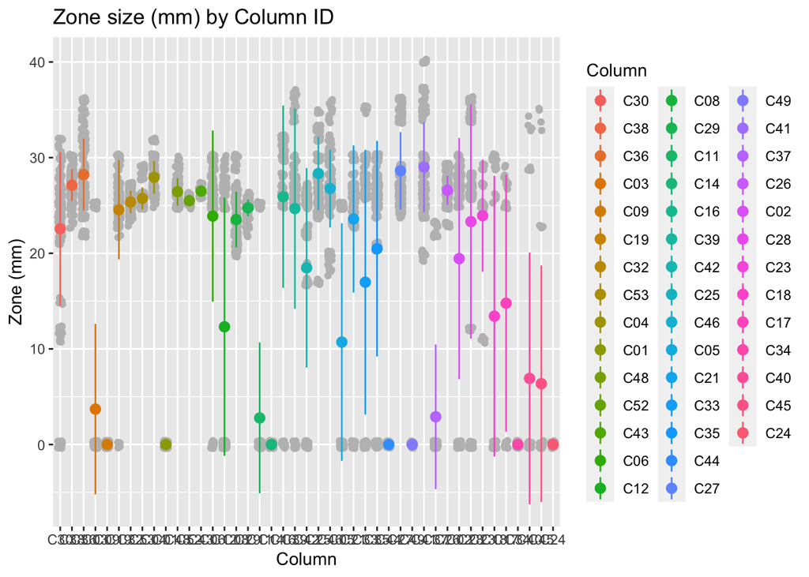

Now we visualize zone sizes, by treatment, with error bars.

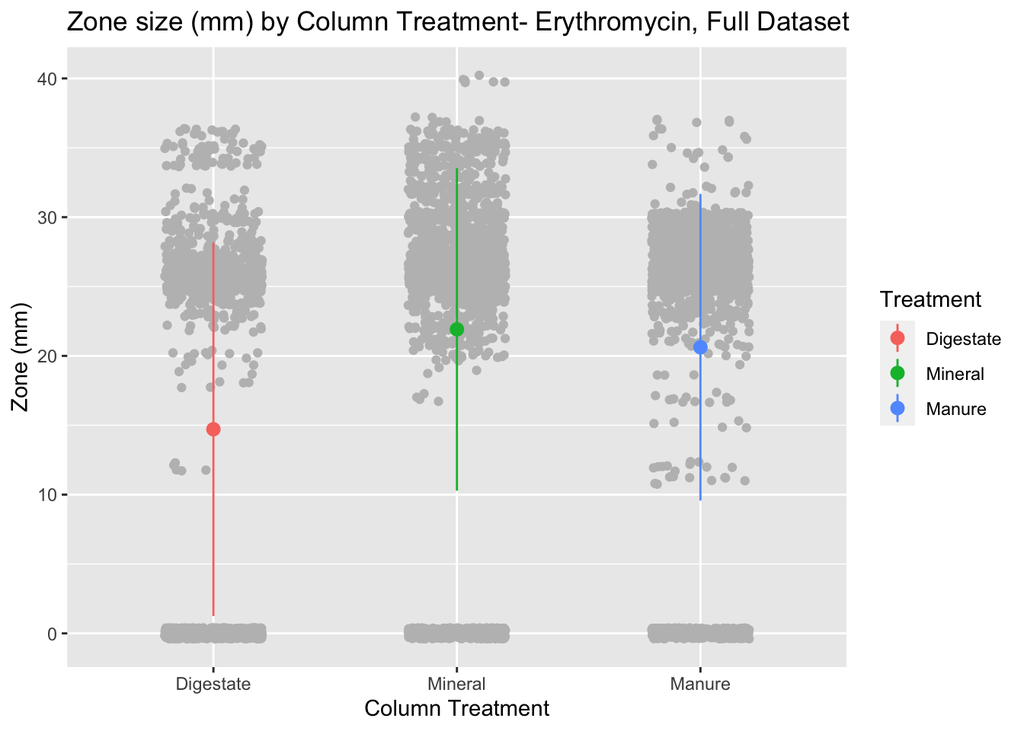

## Summary

To be continued. Please note that (as of 06.12.23) data and figures are using a demo (incomplete) data set only. No conclusions can be made from current iteration.